# Practical Machine Learning Project

Konstantin Zakharov

# Overview

This project utilizes machine learning algorithms to predict the manner in which the 6 participants of the study performed the exercise, based on observations collected from accelerometers placed on the belt, forearm, arm, and dumbbell of the participants. They were asked to perform barbell lifts correctly and incorrectly in 5 different ways. More information is available from the website here: http://groupware.les.inf.puc-rio.br/har

# Summary

This project explored three different models: Random Forests, Classification and Regression Trees (CART), and the Gradient Boosting Machine (GBM) model. To get a more reliable and unbiased estimate of a machine learning model’s performance on unseen (test) data, the project employed the cross-validation technique of k-fold. Comparing the accuracy of 3 models, the final model is the Random Forest with the best accuracy of 99.46%, which was used for the final refit and for predicting on the test data.

# Data Loading and Preparation

First, let’s load the source data and prepare the training dataset. After removing irrelevant data the training dataset consists of 19622 observations for 53 variables.

```r
library(caret)
library(dplyr)

library(lattice)
library(rattle)

set.seed(1234)

# read data
training_df <- read.csv(url("https://d396qusza40orc.cloudfront.net/predmachlearn/pml-training.csv"),header=TRUE)
testing_df <- read.csv(url("https://d396qusza40orc.cloudfront.net/predmachlearn/pml-testing.csv"),header=TRUE)

df <- training_df %>%
  # order by time within subjects
  arrange(user_name, raw_timestamp_part_1, raw_timestamp_part_2) %>%
  # as a factor
  mutate(classe = factor(classe)) %>%
  # remove metadata
  select(-c(1:7)) %>%
  # remove non-numeric, if present
  select(classe, where(is.numeric))

na_rate <- sapply(df, function(x) mean(is.na(x)))
# drop the columns, where almost all values are NA, but keep the "classe" variable
df <- df[, na_rate < 0.95 | names(na_rate) %in% "classe"]

summary(df)
```

```
##  classe     roll_belt        pitch_belt          yaw_belt
##  A:5580   Min.   :-28.90   Min.   :-55.8000   Min.   :-180.00
##  B:3797   1st Qu.:  1.10   1st Qu.:  1.7600   1st Qu.: -88.30
##  C:3422   Median :113.00   Median :  5.2800   Median : -13.00
##  D:3216   Mean   : 64.41   Mean   :  0.3053   Mean   : -11.21
##  E:3607   3rd Qu.:123.00   3rd Qu.: 14.9000   3rd Qu.:  12.90
##           Max.   :162.00   Max.   : 60.3000   Max.   : 179.00
##  total_accel_belt  gyros_belt_x        gyros_belt_y       gyros_belt_z
##  Min.   : 0.00    Min.   :-1.040000   Min.   :-0.64000   Min.   :-1.4600
##  1st Qu.: 3.00    1st Qu.:-0.030000   1st Qu.: 0.00000   1st Qu.:-0.2000
##  Median :17.00    Median : 0.030000   Median : 0.02000   Median :-0.1000
##  Mean   :11.31    Mean   :-0.005592   Mean   : 0.03959   Mean   :-0.1305
##  3rd Qu.:18.00    3rd Qu.: 0.110000   3rd Qu.: 0.11000   3rd Qu.:-0.0200
##  Max.   :29.00    Max.   : 2.220000   Max.   : 0.64000   Max.   : 1.6200
##   accel_belt_x       accel_belt_y     accel_belt_z     magnet_belt_x
##  Min.   :-120.000   Min.   :-69.00   Min.   :-275.00   Min.   :-52.0
##  1st Qu.: -21.000   1st Qu.:  3.00   1st Qu.:-162.00   1st Qu.:  9.0
##  Median : -15.000   Median : 35.00   Median :-152.00   Median : 35.0
##  Mean   :  -5.595   Mean   : 30.15   Mean   : -72.59   Mean   : 55.6
##  3rd Qu.:  -5.000   3rd Qu.: 61.00   3rd Qu.:  27.00   3rd Qu.: 59.0
##  Max.   :  85.000   Max.   :164.00   Max.   : 105.00   Max.   :485.0
##  magnet_belt_y   magnet_belt_z       roll_arm         pitch_arm
##  Min.   :354.0   Min.   :-623.0   Min.   :-180.00   Min.   :-88.800
##  1st Qu.:581.0   1st Qu.:-375.0   1st Qu.: -31.77   1st Qu.:-25.900
##  Median :601.0   Median :-320.0   Median :   0.00   Median :  0.000
##  Mean   :593.7   Mean   :-345.5   Mean   :  17.83   Mean   : -4.612
##  3rd Qu.:610.0   3rd Qu.:-306.0   3rd Qu.:  77.30   3rd Qu.: 11.200
##  Max.   :673.0   Max.   : 293.0   Max.   : 180.00   Max.   : 88.500
##     yaw_arm          total_accel_arm  gyros_arm_x        gyros_arm_y
##  Min.   :-180.0000   Min.   : 1.00   Min.   :-6.37000   Min.   :-3.4400
##  1st Qu.: -43.1000   1st Qu.:17.00   1st Qu.:-1.33000   1st Qu.:-0.8000
##  Median :   0.0000   Median :27.00   Median : 0.08000   Median :-0.2400
##  Mean   :  -0.6188   Mean   :25.51   Mean   : 0.04277   Mean   :-0.2571
##  3rd Qu.:  45.8750   3rd Qu.:33.00   3rd Qu.: 1.57000   3rd Qu.: 0.1400
##  Max.   : 180.0000   Max.   :66.00   Max.   : 4.87000   Max.   : 2.8400
##   gyros_arm_z       accel_arm_x       accel_arm_y      accel_arm_z
##  Min.   :-2.3300   Min.   :-404.00   Min.   :-318.0   Min.   :-636.00
##  1st Qu.:-0.0700   1st Qu.:-242.00   1st Qu.: -54.0   1st Qu.:-143.00
##  Median : 0.2300   Median : -44.00   Median :  14.0   Median : -47.00
##  Mean   : 0.2695   Mean   : -60.24   Mean   :  32.6   Mean   : -71.25
```

[output cut: 43 more lines]

```
##  Max.   :  3.970   Max.   :311.00000   Max.   :231.0000   Max.   : 477.00
##  accel_forearm_y  accel_forearm_z   magnet_forearm_x  magnet_forearm_y
##  Min.   :-632.0   Min.   :-446.00   Min.   :-1280.0   Min.   :-896.0
##  1st Qu.:  57.0   1st Qu.:-182.00   1st Qu.: -616.0   1st Qu.:   2.0
##  Median : 201.0   Median : -39.00   Median : -378.0   Median : 591.0
##  Mean   : 163.7   Mean   : -55.29   Mean   : -312.6   Mean   : 380.1
##  3rd Qu.: 312.0   3rd Qu.:  26.00   3rd Qu.:  -73.0   3rd Qu.: 737.0
##  Max.   : 923.0   Max.   : 291.00   Max.   :  672.0   Max.   :1480.0
##  magnet_forearm_z
##  Min.   :-973.0
##  1st Qu.: 191.0
##  Median : 511.0
##  Mean   : 393.6
##  3rd Qu.: 653.0
##  Max.   :1090.0
```

## Data slicing

To decrease the bias and/or over-/under-fitting I employ the cross-validation by splitting the provided training data set into sub-sets of training and test subs. Taking into account the input, it would make sense to split data into contiguous time blocks, using e.g. `createTimeSlices`, if the performance was acceptable. Thus, for this project I skip the time-awareness and employ the simple k-fold CV of 3.

```r
ctrl <- trainControl(method = "cv",
                     number = 3,
                     savePredictions = "final",
                     allowParallel = TRUE
)

# use all variables as predictors
base_formula <- classe ~ .
```

## Note on Data Impute

I removed only the columns with almost all NAs, but there are still NA values present for a few observations. To increase coverage, I fill the missing data the median value, refer to the `medianImpute` pre-processing. The `caret` will fit the imputer on each training slice only and apply it to the corresponding validation slice.

# Building the models

## Initial models

### Random Forest

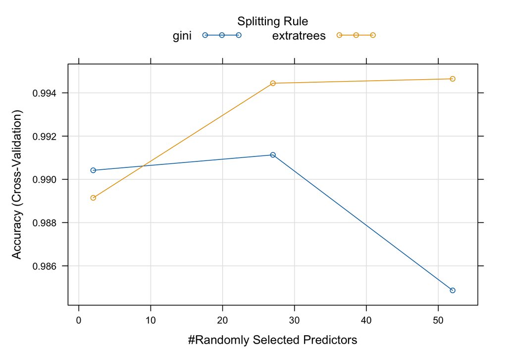

```r
fit_rf <- train(
  base_formula,
  data = df,
  method     = "ranger",
  trControl  = ctrl,
  preProcess = "medianImpute",
  num.trees  = 50,
  importance = "impurity"
)

plot(fit_rf, metric = "Accuracy")   # caret plots Accuracy vs mtry
```

### Gradient Boosting

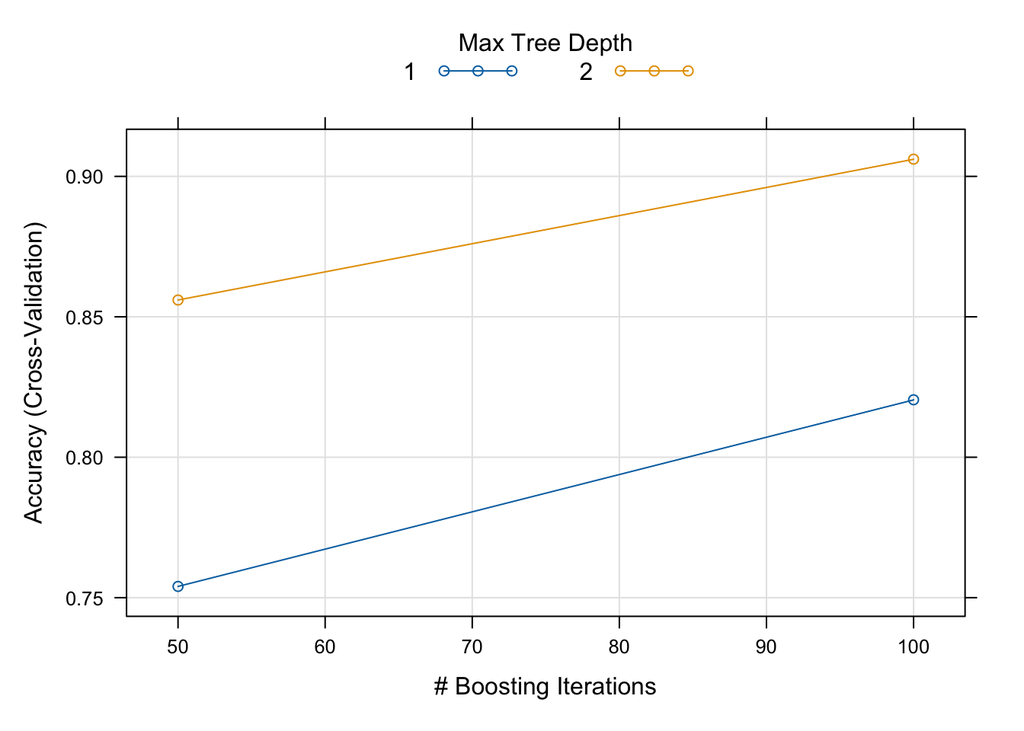

```r
fit_gbm <- train(
  base_formula,
  data = df,
  method     = "gbm",
  trControl  = ctrl,
  preProcess = "medianImpute",
  tuneLength = 2,
  verbose    = FALSE
)
plot(fit_gbm, metric = "Accuracy")  # shows performance across n.trees
```

### Decision Tree

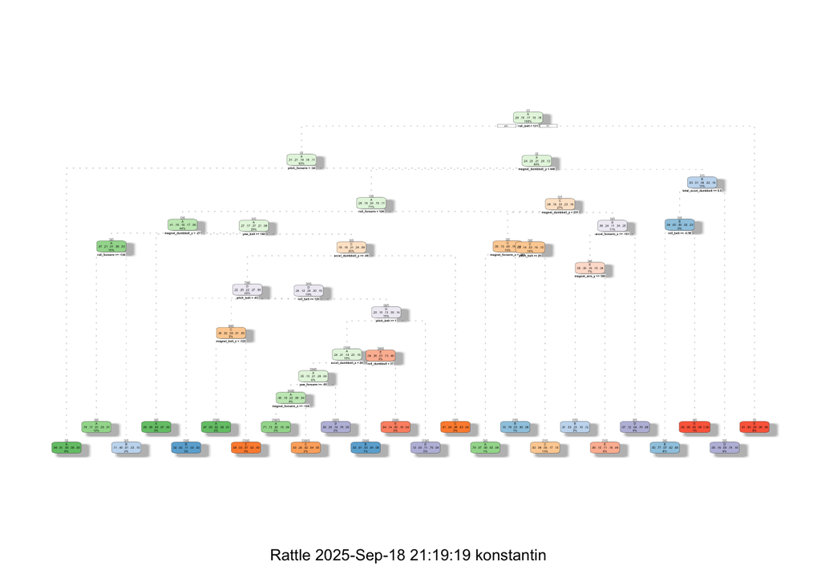

```r
fit_cart <- train(
  base_formula,
  data = df,
  method     = "rpart",
  trControl  = ctrl,
  preProcess = "medianImpute",
  tuneGrid   = data.frame(cp = 0.01)
)
fancyRpartPlot(fit_cart$finalModel)
```

## Expected Sample Error and Choosing the winner

```r
fit_info_rf <- subset(
  fit_rf$pred,
  mtry == fit_rf$bestTune$mtry &
    splitrule == fit_rf$bestTune$splitrule &
    min.node.size == fit_rf$bestTune$min.node.size
)

fit_info_gbm <- subset(
  fit_gbm$pred,
  n.trees == fit_gbm$bestTune$n.trees &
    interaction.depth == fit_gbm$bestTune$interaction.depth &
    shrinkage == fit_gbm$bestTune$shrinkage &
    n.minobsinnode == fit_gbm$bestTune$n.minobsinnode
)

fit_info_cart <- subset(
  fit_cart$pred,
  cp == fit_cart$bestTune$cp
)

format_accuracy_row <- function(name, p) {
  n <- nrow(p); correct <- sum(p$pred == p$obs, na.rm = TRUE)
  acc <- correct / n
  ci  <- binom.test(correct, n)$conf.int
  data.frame(
    Model            = name,
    Accuracy         = sprintf("%.2f%%", 100 * acc),
    `Accuracy 95%% CI` = sprintf("%.2f–%.2f%%", 100 * ci[1], 100 * ci[2]),
    `Expected error` = sprintf("%.2f%%", 100 * (1 - acc)),
    `Error 95%% CI`  = sprintf("%.2f–%.2f%%", 100 * (1 - ci[2]), 100 * (1 - ci[1])),
    N = n,
    check.names = FALSE
  )
}

accuracy_table <- rbind(
  format_accuracy_row("RF",   fit_info_rf),
  format_accuracy_row("GBM",  fit_info_gbm),
  format_accuracy_row("CART", fit_info_cart)
)

print(accuracy_table, row.names = FALSE)
```

```
##  Model Accuracy Accuracy 95%% CI Expected error Error 95%% CI     N
##     RF   99.46%     99.35–99.56%          0.54%    0.44–0.65% 19622
##    GBM   90.61%     90.20–91.02%          9.39%    8.98–9.80% 19622
##   CART   74.53%     73.91–75.14%         25.47%  24.86–26.09% 19622
```

The best accuracy is 99.46% for the Random Forest (Ranger) model.

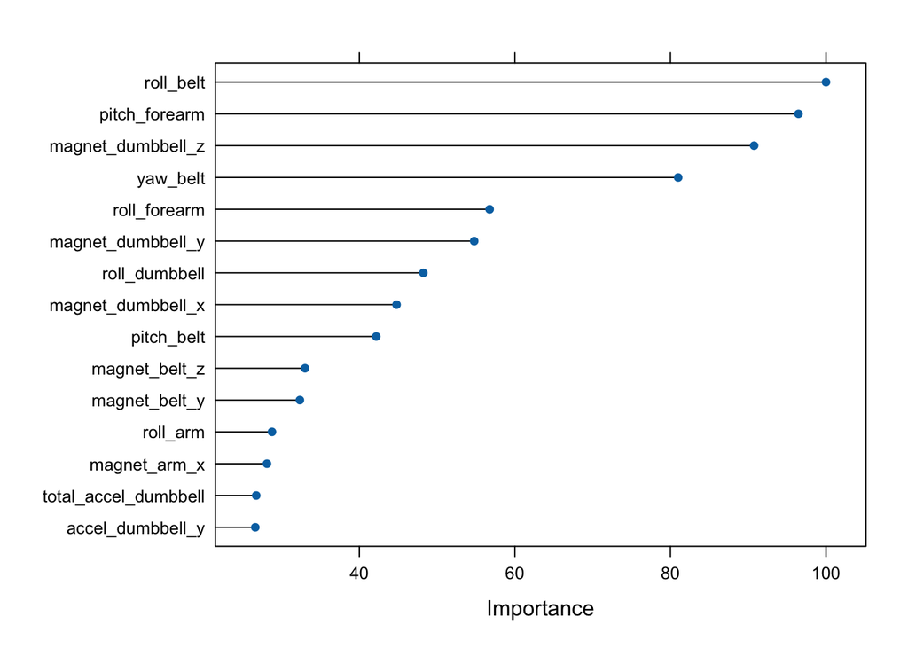

```r
plot(varImp(fit_rf), top = 15)
```

# Predicting on the Test Dataset

## Final Model

Let’s first re-train the model to use the `bestTune` of Random Forest model.

```r
final_rf <- train(
  base_formula,
  data      = df,
  method    = "ranger",
  trControl = trainControl(method = "none"),
  tuneGrid  = fit_rf$bestTune,
  preProcess = "medianImpute",
  num.trees = 300
)
```

## Prediction

Using the refitted model, we can predict the `classe` for the test data:

```r
predict(final_rf, newdata = testing_df)
```

```
##  [1] B A B A A E D B A A B C B A E E A B B B
## Levels: A B C D E
```